# Tidy Tuesday: Symbiosis Biomarker Expression During Coral Development

Erin Chille

Last updated: 2020/11/13

## Set up workspace

Remove prior objects and load necessary tools

```r
rm(list=ls()) # removes all prior objects

library("RColorBrewer")
library("ggplot2")
library("tidyverse")
library("ggpubr")
library("DESeq2")
```

Load sample metadata

```r
sample.info <- read.csv(file="https://raw.githubusercontent.com/echille/Mcapitata_Developmental_Gene_Expression_Timeseries/master/Sample_Info/RNAseq_data.csv", header=T, sep=",") #load sample info
```

Load gene count information

```r
counts <- as.data.frame(read.csv("https://raw.githubusercontent.com/echille/Mcapitata_Developmental_Gene_Expression_Timeseries/master/1-QC-Align-Assemble/Output/gene_count_matrix.csv", row.names="gene_id"), colClasses = double) #Load normalized expression matrix from stringtie
```

Keep only ambient treatmentinfo and count data

```r
dev <- c("AMB")
treatmentinfo_dev <- filter(sample.info, treatment %in% dev)
dim(treatmentinfo_dev) #rows should be 24
```

```
## [1] 24  4
```

```r
gcount_dev <- counts[treatmentinfo_dev$sample_id]
dim(gcount_dev) #columns should be 24
```

```
## [1] 63227    24
```

### Read normalization

We are now going normalize our read counts using VST-normalization in DESeq2

#### Construct the DESeq2 dataset

Merge the treatment and time_point columns into a new column , group. Set group as a factor.

```r
treatmentinfo_dev$time_point <- factor(treatmentinfo_dev$time_point, levels = c("Unfertilized_egg", "Fertilized_egg", "Cleavage", "Prawn_chip", "Early_gastrula", "Mid_gastrula", "Late_gastrula", "Planula", "Adult"))
```

Create a DESeqDataSet design from gene count matrix and labels. Here we set the design to look at time_point to test for any differences in gene expression across timepoints.

```r
#Set DESeq2 design
gdds_dev <- DESeqDataSetFromMatrix(countData = gcount_dev,
                              colData = treatmentinfo_dev,
                              design = ~time_point)
```

#### Log-transform the count data

First we are going to log-transform the data using a variance stabilizing transforamtion (VST). This is only for visualization purposes. Essentially, this is roughly similar to putting the data on the log2 scale. It will deal with the sampling variability of low counts by calculating within-group variability (if blind=FALSE). Importantly, it does not use the design to remove variation in the data, and so can be used to examine if there may be any variability due to technical, factors such as extraction batch effects.

To do this we first need to calculate the size factors of our samples. This is a rough estimate of how many reads each sample contains compared to the others. In order to use VST (the faster log2 transforming process) to log-transform our data, the size factors need to be less than 4. Otherwise, there could be artefacts in our results.

```r
SF.gdds_dev <- estimateSizeFactors(gdds_dev) #estimate size factors to determine if we can use vst  to transform our data. Size factors should be less than four to use vst
print(sizeFactors(SF.gdds_dev)) #View size factors
```

```
##      X119      X120      X121      X127      X132      X153      X154      X159
## 1.0519967 0.5686680 0.7558557 0.5351080 0.5251546 1.0029584 1.8794576 0.7811492
##      X162      X163      X167      X179      X180      X184      X212      X215
## 1.5226504 1.7499897 1.7848493 1.0151292 0.8308898 0.9339607 1.1350398 0.8053938
##      X218      X221      X359      X361      X375     X1101     X1548     X1628
## 1.6504284 1.1560682 1.4281348 1.3679823 1.0904351 1.2882416 0.8315212 0.9180700
```

Our size factors are all less than 4, so we can transform using VST!

```r
gvst_dev <- vst(gdds_dev, blind=FALSE) #apply a variance stabilizing transformation to minimize effects of small counts and normalize wrt library size
```

## Find symbiosis biomarkers

I searched the [annotation file](https://github.com/echille/Mcapitata_Developmental_Gene_Expression_Timeseries/blob/master/0-BLAST-GO-KO/Output/200824_Mcap_Blast_GO_KO.tsv) for GO terms associated with the coral-zooxanthella relationship.

I specifically searched for the GO terms:

- reduction of food intake in response to dietary excess [GO:0002023]… 1 occurrence
- response to glucose [GO:0009749]… 1 occurrence
- glucose catabolic process [GO:0006007]… 2 occurrences
- glucose metabolic process [GO:0006006]… 4 occurrences
- sphingosine biosynthetic process [GO:0046512]… 38 occurrences
- carbohydrate metabolic process [GO:0005975]… 201 occurrences
- transmembrane transport [GO:0055085]… 645 occurrences

For simplicity of expression plots, only “response to glucose”, “glucose catabolic process”, and “glucose metabolic process” will be plotted. Interestingly, the one occurrence of “reduction of food intake in response to dietary excess” was the same gene with the functional annotation, “response to glucose”.

## Create a dataframe containing the mean counts of your target genes

First, make a dataframe containing our target genes and their associated GO term

```r
targets <- data.frame(
  association = c("glucose_metabolism", "glucose_metabolism", "glucose_metabolism", "glucose_metabolism", "glucose_catabolism", "glucose_catabolism", "response_to_glucose"),
  gene_id = c("adi2mcaRNA23963_R0", "g24226", "g27646", "g30302", "adi2mcaRNA32619_R0", "g64471", "g16598")
)
```

Then, subset results for genes of interest

```r
countsx <- as.data.frame(assay(gvst_dev))
gene.counts <- countsx[(row.names(countsx) %in% targets$gene_id), ]
#str(gene.counts)
gene.counts$gene_id <- row.names(gene.counts)
gene.counts <- merge(gene.counts, targets, by="gene_id")
```

Calculate the mean and standard error of expression at each timepoint. To do this, we have to transform the table to a “long” version.

```r
gene.counts.long <- pivot_longer(gene.counts, 2:25, values_to = "exp")
  #gather(gene.counts, group, exp, X1101:X375, factor_key=TRUE)
colnames(gene.counts.long)[3] <- "sample_id"
gene.counts.long <- merge(gene.counts.long, sample.info[,c(1:2)], by="sample_id")
#str(gene.counts.long)

mean.counts <- gene.counts.long %>%
  group_by(gene_id, time_point) %>%
  summarise(mean = mean(exp),
            sd=sd(exp))
mean.counts$time_point <- factor(mean.counts$time_point,
                                 levels = c("Unfertilized_egg","Fertilized_egg","Cleavage",
                                  "Prawn_chip","Early_gastrula","Mid_gastrula", "Late_gastrula",
                                  "Planula", "Adult"))
mean.counts <- merge(mean.counts, targets, by= "gene_id")
```

## Plot expression

Glucose metabolism

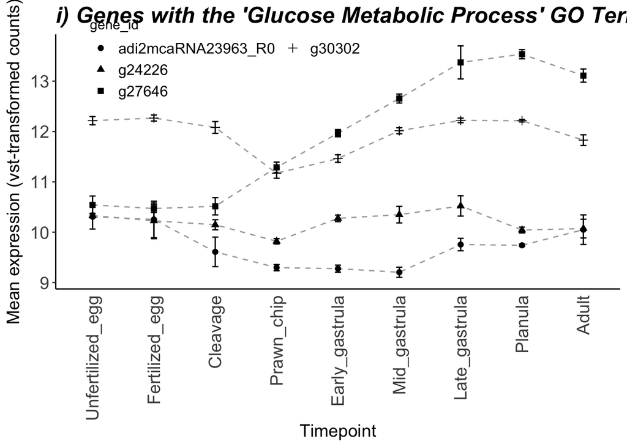

```r
Mcap.met <- mean.counts %>% subset(association =="glucose_metabolism") %>% ggplot(aes(x=time_point, y=mean, group=gene_id)) +
  geom_errorbar(aes(ymin=mean-sd, ymax=mean+sd), width=.1) +
  geom_line(aes(shape=gene_id), lty="dashed", color = "darkgrey") +
  geom_point(aes(shape=gene_id), size = 2, ) +
  xlab("Timepoint") +
 ylab(expression(paste("Mean expression (vst-transformed counts)"))) +
  theme_bw() + #Set the background color
  theme(axis.line = element_line(color = 'black'), #Set the axes color
        panel.border = element_blank(), #Set the border
        panel.grid.major = element_blank(), #Set the major gridlines
        panel.grid.minor = element_blank(), #Set the minor gridlines
        plot.background=element_blank(),  #Set the plot background
        axis.title.x=element_text(size = 14), #set x-axis title size
        axis.text.x=element_text(angle = 90, vjust = 0.5, hjust=1, size = 14), #set x-axis label size
        axis.text.y=element_text(size = 14), #set x-axis label size
        axis.title.y=element_text(size = 14), #set x-axis label size
        axis.ticks.x=element_blank(), #No x-label ticks
        legend.text=element_text(size = 12), #Legend text size
        legend.position=c(0.3, 0.9)) +
  guides(shape=guide_legend(nrow=3)) +
  ggtitle("i) Genes with the 'Glucose Metabolic Process' GO Term") +
  #facet_grid(rows=vars(gene_id), scales="free_y") +
  theme(strip.text.y = element_text(size = 5)) +
  theme(plot.title = element_text(face = 'bold.italic',
                                  size = 18,
                                  hjust = 0))
Mcap.met
```

Glucose catabolism

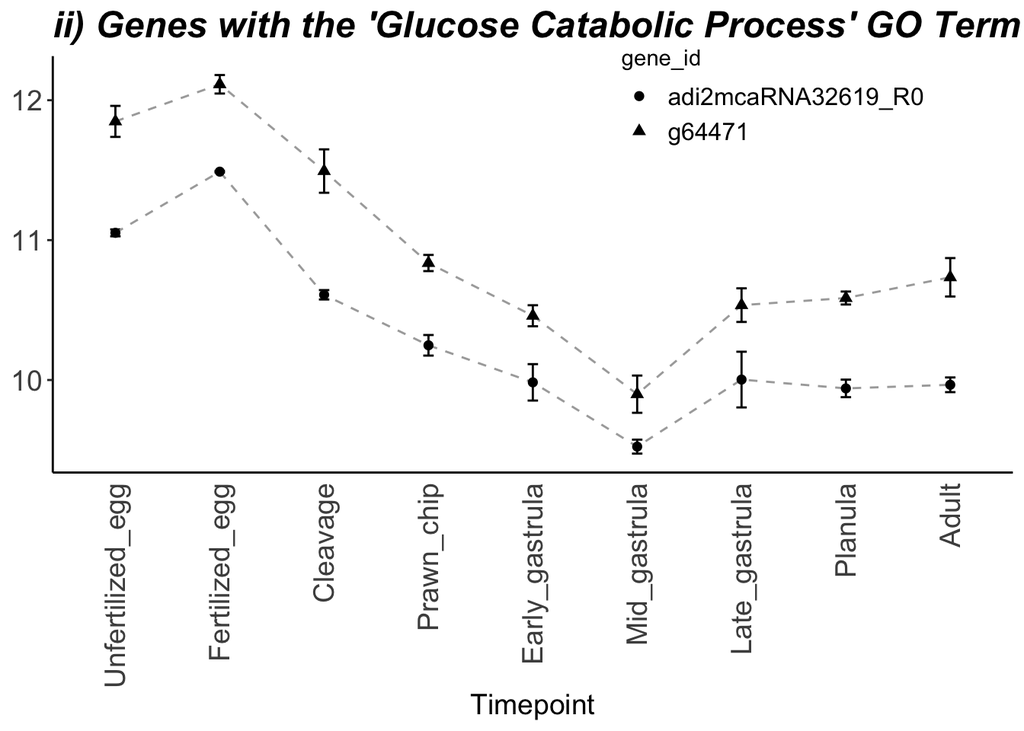

```r
Mcap.cat <- mean.counts %>% subset(association =="glucose_catabolism") %>% ggplot(aes(x=time_point, y=mean, group=gene_id)) +
  geom_errorbar(aes(ymin=mean-sd, ymax=mean+sd), width=.1) +
  geom_line(aes(shape=gene_id), lty="dashed", color = "darkgrey") +
  geom_point(aes(shape=gene_id), size = 2, ) +
  xlab("Timepoint") +
  ylab(expression(paste("Mean expression (vst-transformed counts)"))) +
  theme_bw() + #Set the background color
  theme(axis.line = element_line(color = 'black'), #Set the axes color
        panel.border = element_blank(), #Set the border
        panel.grid.major = element_blank(), #Set the major gridlines
        panel.grid.minor = element_blank(), #Set the minor gridlines
        plot.background=element_blank(),  #Set the plot background
        axis.title.x=element_text(size = 14), #set x-axis title size
        axis.text.x=element_text(angle = 90, vjust = 0.5, hjust=1, size = 14), #set x-axis label size
        axis.text.y=element_text(size = 14), #set x-axis label size
        axis.title.y=element_blank(), #set x-axis label size
        axis.ticks.x=element_blank(), #No x-label ticks
        legend.text=element_text(size = 12), #Legend text size
        legend.position = c(0.75, 0.9)) +
  #guides(shape=guide_legend(ncol=2)) +
  ggtitle("ii) Genes with the 'Glucose Catabolic Process' GO Term") +
  #facet_grid(rows=vars(gene_id), scales="free_y") +
  theme(strip.text.y = element_text(size = 5)) +
  theme(plot.title = element_text(face = 'bold.italic',
                                  size = 18,
                                  hjust = 0))
Mcap.cat
```

Response to glucose/reduction of food intake in response to dietary excess

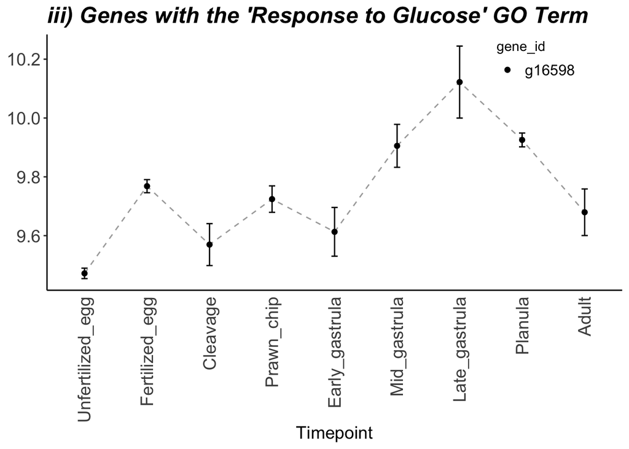

```r
Mcap.resp <- mean.counts %>% subset(association =="response_to_glucose") %>% ggplot(aes(x=time_point, y=mean, group=gene_id)) +
  geom_errorbar(aes(ymin=mean-sd, ymax=mean+sd), width=.1) +
  geom_line(aes(shape=gene_id), lty="dashed", color = "darkgrey") +
  geom_point(aes(shape=gene_id), size = 2, ) +
  xlab("Timepoint") +
  ylab(expression(paste("Mean expression (vst-transformed counts)"))) +
  theme_bw() + #Set the background color
  theme(axis.line = element_line(color = 'black'), #Set the axes color
        panel.border = element_blank(), #Set the border
        panel.grid.major = element_blank(), #Set the major gridlines
        panel.grid.minor = element_blank(), #Set the minor gridlines
        plot.background=element_blank(),  #Set the plot background
        axis.title.x=element_text(size = 14), #set x-axis title size
        axis.text.x=element_text(angle = 90, vjust = 0.5, hjust=1, size = 14), #set x-axis label size
        axis.text.y=element_text(size = 14), #set x-axis label size
        axis.title.y=element_blank(), #set x-axis label size
        axis.ticks.x=element_blank(), #No x-label ticks
        legend.text=element_text(size = 12), #Legend text size
        legend.position = c(0.85, 0.9)) +
  #guides(shape=guide_legend(ncol=2)) +
  ggtitle("iii) Genes with the 'Response to Glucose' GO Term") +
  #facet_grid(rows=vars(gene_id), scales="free_y") +
  theme(strip.text.y = element_text(size = 5)) +
  theme(plot.title = element_text(face = 'bold.italic',
                                  size = 18,
                                  hjust = 0))
Mcap.resp
```

Compile plots into single figure and save

```r
gluc_response <- cowplot::plot_grid(Mcap.met, Mcap.cat, Mcap.resp, align = "vh", ncol = 3)
ggsave("figures/2020-11-10-Symbiosis-biomarker-expression.pdf", gluc_response, width=21, height=7.5)
```